Regresión Lineal Múltiple - Semana 09

Freddy Hernández

fhernanb@unal.edu.co

Profesor Asociado - Departamento de Estadística

Universidad Nacional de Colombia, Sede Medellín

1 / 25

¿Se pueden comparar los efectos (β) de las variables?

Considere el modelo de RLM:

Yi=β0+β1Xi1+β2Xi2+··· +βkXik +εi,con εi

i.i.d

∼N0, σ2.

1. Si las variables predictoras no están en una misma escala de medida, no podemos

determinar cual tiene mayor o menor efecto parcial sobre la respuesta promedio, en

presencia de las demás, esto es, la magnitud de

βj

reﬂeja las unidades de la variable

Xj.

2. Para hacer comparaciones en forma directa de los coeﬁcientes de regresión se

recurre al uso de variables escaladas, tanto en la respuesta como en las predictoras.

2 / 25

[figure not shown]

Escalamiento de longitud unitaria

Cada variable se puede escalar restando su media muestral y dividiendo esta diferencia

por la raiz cuadrada de la suma de cuadrados corregida de cada variable, es decir,

Y∗

i=Yi−¯

Y

sn

P

h=1Yh−¯

Y2=Yi−¯

Y

pSyy

,X∗

ij =Xij −¯

Xj

sn

P

h=1Xhj −¯

Xj2=Xij −¯

Xj

√Sxx

,

con (i=1,2,...,n

j=1,2,...,k

3 / 25

Escalamiento normal unitario

Cada variable se puede escalar restando su media muestral y dividiendo esta diferencia

por la desviación muestral cada variable, es decir,

Y∗

i=Yi−¯

Y

Sy

,X∗

ij =Xij −¯

Xj

Sj

,

con (i=1,2,...,n

j=1,2,...,k

4 / 25

¿Qué hace luego de tener las variables escaladas?

Luego, se ajusta el modelo de RLM sin intercepto:

Y∗

i=β∗

1X∗

i1+β∗

2X∗

i2+··· +β∗

kX∗

ik +εi,con εi

i.i.d

∼N0, σ2

5 / 25

Los coeﬁcientes β∗

json llamados coeﬁcientes de regresión estandarizados, y estos

pueden ser comparados directamente teniendo en cuenta que siguen siendo coeﬁcientes

de regresión parcial, es decir, β∗

jmide el efecto de X∗

jdado que las demás variables

predictoras están en el modelo.

Además, los

β∗

j

pueden servir para determinar la importancia relativa de X

∗

j

en presencia

de las demás variables, en la muestra o conjunto de datos particular considerado para el

ajuste.

6 / 25

Multicolinealidad

Multicolinealidad es la existencia de dependencia casi lineal entre variables predictoras en

el modelo de RLM.

Si existiera dependencia lineal exacta entre dos o más variables predictoras, la matriz

X⊤Xsería singular y por tanto no podríamos hallar los estimadores de mínimos

cuadrados!

7 / 25

Causas de la multicolinealidad

1. El método de recolección de datos que se empleó (subespacios).

2. Restricciones en el modelo o en la población (variables correlacionadas de hecho).

3. Especiﬁcación del modelo (polinomios).

4. Un modelo sobredeﬁnido (más variables que observaciones).

8 / 25

Efectos de la multicolinealidad

Algunos de los efectos más notorios de la multicolinealidad son:

1. Inﬂación de las varianzas de los estimadores: consiste en la inﬂación de los

valores c

∗

jj

en las varianzas de los estimadores Var (

b

β∗

j

) =

σ2

c

∗

jj

,cuando se considera

un modelo con variables escaladas de longitud unitaria, en cuyo caso se puede

demostrar que:

c∗

jj =1

1−R2

j

,

donde R2

jes el coeﬁciente de determinación muestral obtenido de una regresión de Xj

(como respuesta) en función de las otras variables predictoras consideradas en el modelo

(actuando como predictoras de la primera).

9 / 25

2. b

βjmuy grandes en términos absolutos: esto se maniﬁesta en una traza muy

grande de la matriz X⊤X−1, donde: traza X⊤X−1=Pp

j=11

λj, λj>0 es el

j-ésimo valor propio (usualmente ordenados de mayor a menor) de la matriz X⊤X.

Si la

traza X⊤X−1

es muy grande, mayor es la distancia entre el vector de parámetros

estimados y el verdadero valor del vector de parámetros.

10 / 25

3. Valores de los coeﬁcientes con signo contrario a lo esperado: esto puede ser

causado por la presencia de multicolinealidad.

4. Regresión signiﬁcativa pero ninguna variable individualmente signiﬁcativa:

otra de las maneras en que se puede manifestar la multicolinealidad grave es cuando

el modelo de regresión ajustado es signiﬁcativo (según la prueba Fde la tabla

ANOVA) pero individualmente, ninguno de los coeﬁcientes asociados a las variables

predictoras resulta signiﬁcativo (según las pruebas Tde signiﬁcancia individual).

11 / 25

Diagnósticos de la multicolinealidad

Entre los diagnósticos más usados para detectar multicolinealidad en un modelo se

tienen:

1. Examinar la matriz de correlaciones entre las predictoras: sea Cor(X)una

matriz cuyo elemento (j,k) corresponde a la correlación entre las predictoras Xjy

Xk, Cor (Xj,Xk).

Esta matriz resulta útil para detectar multicolinealidad si en ésta no intervienen más de

dos variables en una dependencia casi lineal.

También valores de Cor (Xj,Xk)pequeños no necesariamente implican la ausencia de

multicolinealidad.

12 / 25

2. Factores de Inﬂación de Varianza: se denota como VIFj,j=1,...,ky se

calculan como: VIFj=c∗

jj =1

1−R2

j

. El valor de R2

jes el coeﬁciente de

determinación cuando se hace una regresion de X

j

como respuesta versus las demás

covariables.

A continuación se establece el criterio para detectar la multicolinealidad de acuerdo a

esta medida.

▶Si VIFj≤5 no hay problemas de multicolinealidad.

▶Si 5 <VIFj≤10 hay problemas de multicolinealidad moderada.

▶Si VIFj>10 hay problemas de multicolinealidad graves.

13 / 25

3.

Análisis de los valores propios de X

⊤

X: se trata de evaluar si hay valores propios

con valores cercanos a cero. Para ello se deﬁnen las medidas que se presentan a

continuación:

Número de condición: mide la dispersión en el espectro de los valores propios de la

matriz X⊤X. Se calcula como: κ=λmax/λmin. En Rse obtienen valores en raíz

cuadrada, es decir, √κ,para el cual el criterio para detectar multicolinealidad es:

▶Si √κ≤10 no hay problemas de multicolinealidad.

▶Si 10 <√κ≤31.62 hay problemas de multicolinealidad moderada.

▶Si √κ > 31.62 hay problemas de multicolinealidad graves.

14 / 25

Índice de condición: es una medida útil para determinar el número de dependencias

casi lineales en X⊤X. Se calcula como: κj=λmax/λj,j=1,...,p(en Rse obtienen

los valores √κj). El criterio para detectar multicolinealidad es:

▶Si √κj≤10 ∀j, no hay problemas de multicolinealidad.

▶Si al menos para un j, 10 <√κj≤31.62, entonces hay problemas de

multicolinealidad moderada.

▶Si al menos para un j,√κj>31.62, entonces hay problemas de multicolinealidad

graves (por lo menos hay una asociación casi lineal entre dos o más predictoras).

15 / 25

Proporciones de descomposición de varianza: denotados πij representan la

proporción de la varianza de cada b

βj(o de cada factor de inﬂación de varianza) debida

al i-ésimo valor propio de la matriz X⊤X.

Proporciones altas (

πij >

0

.

5) para dos o más coeﬁcientes de regresión asociados con un

mismo valor propio pequeño es evidencia de multicolinealidad entre las variables

correspondientes a tales coeﬁcientes.

NOTA: El análisis de valores propios se puede realizar usando datos centrados o con los

datos originales.

16 / 25

Selección de variables (construcción de un modelo)

En algunos estudios observacionales o exploratorios se parte de un modelo de regresión

en el que se considera un conjunto grande de variables predictoras potenciales para luego

identiﬁcar un subconjunto entre tales variables, que resulte potencialmente útil para

construir el modelo de regresión ﬁnal.

Dependiendo de los usos que se deseen dar a un modelo de regresión variará el

subconjunto de variables seleccionadas. Por ejemplo, desde el punto de vista del ajuste,

cierto subgrupo de variables serán útiles, en tanto que desde el punto de vista del

pronóstico, otro subconjunto podría resultar ser mejor. Es necesario ﬁjar un criterio de

selección del mejor subconjunto de variables.

17 / 25

Método de todas las regresiones posibles

Este procedimiento consiste en correr todos los 2

k−

1 modelos posibles (con intercepto)

de la variable respuesta vs. los posibles subconjuntos de variables predictoras,

k

1!=kmodelos de una predictora

k

2!modelos de dos predictoras

.

.

.

k

k!=1 modelo de kpredictoras

2k−1 modelos posibles,

y comparar tales modelos con base en criterios estadísticos.

18 / 25

Criterios estadísticos en la comparación de modelos

▶R2

p

: el mejor modelo es aquel con el mayor valor en este estadístico, sin embargo, al

ser una función no decreciente del número de predictoras, tiende a señalar al

modelo con todas las predictoras.

Con el ﬁn de resolver esta diﬁcultad, se busca un modelo con un menor número de

variables cuyo R2no cambie signiﬁcativamente al aumentar el número de predictoras.

19 / 25

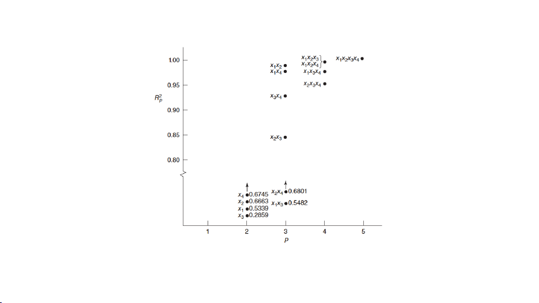

Ilustración criterio R2

p

(Fuente: Mongomery et al. (2002))

20 / 25

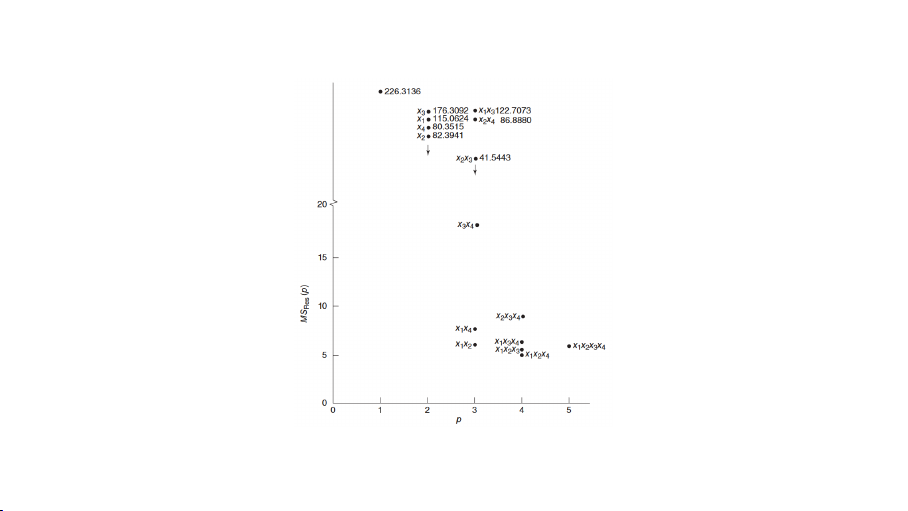

▶R2

adj,p (o MSEp): el mejor modelo es aquel con mayor (menor) valor en este

estadístico.

(Fuente: Mongomery et al. (2002))

21 / 25

▶Cpde Mallows: el mejor modelo es aquél para el cual Cpes el más pequeño

posible (es decir, el modelo con el menor número de variables predictoras posible) y

tal que la diferencia |Cp−p|es mínima, con pigual al número de parámetros del

modelo considerado, incluyendo el intercepto.

Este estadístico es una medida del sesgo en el modelo de regresión, es decir, de

Eb

Yi−µi, y es tal que a mayor sesgo, mayor Cp. Este estadístico se calcula como:

Cp=SSEp

MSE (β0, β1, . . . , βk)−(n−2p)

donde SSEpes la suma de cuadrados del error del modelo considerado y

MSE (β0, β1, . . . , βk)es el cuadrado medio del error para el modelo de regresión con

todas las kvariables.

22 / 25

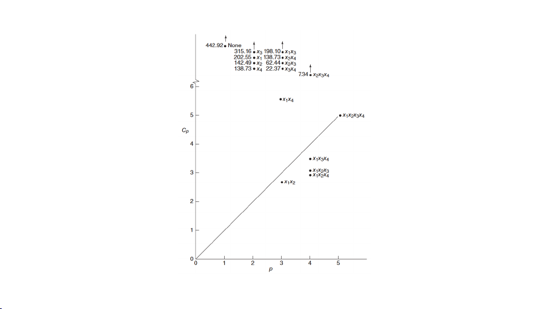

Ilustración criterio Cp

(Fuente: Mongomery et al. (2002))23 / 25

▶PRESSpo suma de cuadrados de predicción: mide qué también el uso de los

valores ajustados por un submodelo puede predecir las respuestas observadas.

Mientras menor sea esta medida, mejor se considera el modelo.

El PRESS es como un SSE, pero en el cual el valor ajustado para cada observación Y

i

se

halla estimando el submodelo sin considerar dicha observación, tales valores ajustados se

denotan por b

Y(i); así el PRESS es la suma de cuadrados de los residuales de predicción

e(i)=Yi−b

Y(i), es decir, PRESSp=n

P

i=1

e2

(i).

24 / 25

Para cada submodelo, la deﬁnición del error de predicción implica correr nregresiones

separadas (cada una con n

−

1 datos) con cada observación eliminada en cada caso, sin

embargo, basta con correr una vez el modelo con todas las observaciones, hallar sus

residuales ordinarios, y los elementos de la diagonal principal de la matriz hat y calcular

e(i)=ei/(1−hii ).

Si se usan dos o más criterios de selección de modelos, es posible que cada criterio lleve

a modelos distintos.La decisión ﬁnal debe basarse en el análisis de residuales y otros

diagnósticos, además de complementar con el conocimiento y la experiencia de personas

expertas en el ámbito en el cual está inmerso el problema.

25 / 25